# 02 Descriptives

The ‘Immigration Issue’ Misnomer in Human Capital Research: Intersectional Inequalities in Adult Education and Literacy in Upper- and Middle-Income Countries

Nate Breznau

The first cycle of PIAAC is included to demonstrate change in literacy across countries.

Many functions are stored in the /Sub folder and called in this workflow.

## 1 Setup

## 2 Data

## 3 Fig A1. Immigrant Literacy 2012 and 2022

### 3.1 Get rates for each country

Run the routine country_loop.R once and then simply load the results thereafter as the saved object plot_df.RData

### 3.2 Build

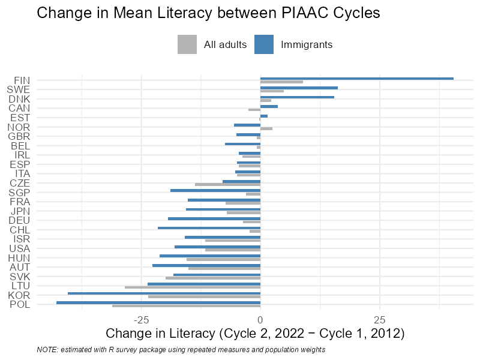

## 4 Tbl S1. Immigration Increases 1990-2024

UN. 2024. “Total Number of Emigrants: People That Were Born in a Country and Now Live in Another Country” [CSV]. Our World In Data: United Nations Department of Economic and Social Affairs. https://ourworldindata.org/migration.

UN. 2024. “Share of The Population That Were Born in Another Country” [CSV]. Our World In Data: United Nations Department of Economic and Social Affairs. https://ourworldindata.org/grapher/migrant-stock-share

Files downloaded 2025/12/05

| Entity | emigrants_2024 | pct_change_1990_2024 | population_2024 | pct_emig_2024 | pct_fb_2024 | pct_fb_1990 |
| --- | --- | --- | --- | --- | --- | --- |
| Africa | 45750673 | 132.49810 | 1291044964 | 3.5 | 1.9 | 2.5 |
| Asia | 120717155 | 122.91332 | 4042291127 | 3.0 | 1.9 | 1.5 |
| Europe | 61061575 | 24.86158 | 928263208 | 6.6 | 18.4 | 9.6 |
| North America | 31580108 | 139.35463 | 381464223 | 8.3 | 10.8 | 7.1 |
| Oceania | 1602503 | 95.48417 | 46000000 | 3.5 | 21.5 | 17.8 |
| South America | 21243834 | 418.78533 | 662186388 | 3.2 | 2.9 | 1.5 |
| World | 281955848 | 100.19000 | 7305249910 | 3.9 | 3.7 | 2.9 |

## 5 Table A1. Descriptives

### 5.1 All

Descriptive Statistics

| variable | mean | wmean | sd | min | max | n |
| --- | --- | --- | --- | --- | --- | --- |
| Literacy Skills | 256.39 | 260.88 | 55.40 | 16.76 | 449.50 | 126621 |
| ALE Participation | 0.41 | 0.46 | 0.49 | 0.00 | 1.00 | 124856 |
| female | 0.54 | 0.50 | 0.50 | 0.00 | 1.00 | 126432 |
| Foreign-Born | 0.13 | 0.25 | 0.34 | 0.00 | 1.00 | 123375 |
| Has Children | 0.67 | 0.64 | 0.47 | 0.00 | 1.00 | 126621 |
| Non-Native Speaker | 0.11 | 0.19 | 0.31 | 0.00 | 1.00 | 123375 |
| Primary Education | 0.13 | 0.14 | 0.33 | 0.00 | 1.00 | 124323 |
| Secondary Education | 0.44 | 0.40 | 0.50 | 0.00 | 1.00 | 124323 |
| Tertiary Education | 0.44 | 0.45 | 0.50 | 0.00 | 1.00 | 124323 |
| Listwise Missing Cases | 1.00 | 1.00 | 0.00 | 1.00 | 1.00 | 3805 |
| aweight | 24.50 | 493.24 | 107.16 | 1.00 | 3988.08 | 126621 |

Drop cases of those still in formal education 20478 and do listwise deletion leaving 1.22816^{5} cases for analysis. This is a 6.7371363 percent reduction.

### 5.2 Women

Descriptive Statistics

| variable | mean | wmean | sd | min | max | n |
| --- | --- | --- | --- | --- | --- | --- |
| Literacy Skills | 256.83 | 260.91 | 53.74 | 23.83 | 420.67 | 67669 |
| ALE Participation | 0.42 | 0.47 | 0.49 | 0.00 | 1.00 | 66807 |
| Foreign-Born | 0.13 | 0.25 | 0.34 | 0.00 | 1.00 | 66094 |
| Has Children | 0.73 | 0.69 | 0.45 | 0.00 | 1.00 | 67669 |
| Non-Native Speaker | 0.10 | 0.20 | 0.31 | 0.00 | 1.00 | 66094 |
| Primary Education | 0.12 | 0.13 | 0.32 | 0.00 | 1.00 | 66542 |
| Secondary Education | 0.41 | 0.39 | 0.49 | 0.00 | 1.00 | 66542 |
| Tertiary Education | 0.47 | 0.49 | 0.50 | 0.00 | 1.00 | 66542 |
| Listwise Missing Cases | 1.00 | 1.00 | 0.00 | 1.00 | 1.00 | 1864 |
| aweight | 22.79 | 497.71 | 104.03 | 1.00 | 3988.08 | 67669 |

### 5.3 Men

Descriptive Statistics

| variable | mean | wmean | sd | min | max | n |
| --- | --- | --- | --- | --- | --- | --- |
| Literacy Skills | 255.86 | 260.87 | 57.22 | 16.76 | 449.50 | 58763 |
| ALE Participation | 0.39 | 0.46 | 0.49 | 0.00 | 1.00 | 57862 |
| Foreign-Born | 0.13 | 0.24 | 0.33 | 0.00 | 1.00 | 57098 |
| Has Children | 0.61 | 0.59 | 0.49 | 0.00 | 1.00 | 58763 |
| Non-Native Speaker | 0.10 | 0.18 | 0.31 | 0.00 | 1.00 | 57098 |
| Primary Education | 0.14 | 0.15 | 0.34 | 0.00 | 1.00 | 57599 |
| Secondary Education | 0.47 | 0.42 | 0.50 | 0.00 | 1.00 | 57599 |
| Tertiary Education | 0.40 | 0.42 | 0.49 | 0.00 | 1.00 | 57599 |
| Listwise Missing Cases | 1.00 | 1.00 | 0.00 | 1.00 | 1.00 | 1927 |
| aweight | 26.54 | 489.01 | 110.79 | 1.00 | 3174.53 | 58763 |

### 5.4 Foreign-born, non-native

Means and Weighted Means by Gender

| variable | female_mean | female_wmean | male_mean | male_wmean |
| --- | --- | --- | --- | --- |
| Literacy Skills | 236.16 | 247.32 | 234.02 | 249.38 |
| ALE Participation | 0.42 | 0.52 | 0.42 | 0.53 |
| Foreign-Born | 1.00 | 1.00 | 1.00 | 1.00 |
| Has Children | 0.68 | 0.66 | 0.59 | 0.57 |
| Non-Native Speaker | 1.00 | 1.00 | 1.00 | 1.00 |
| Primary Education | 0.18 | 0.12 | 0.22 | 0.15 |
| Secondary Education | 0.32 | 0.29 | 0.33 | 0.26 |
| Tertiary Education | 0.50 | 0.59 | 0.45 | 0.59 |
| Currently in Education | 0.13 | 0.18 | 0.13 | 0.18 |

## 6 Fig 1. Intersectionality of Literacy

### 6.1 Define all groups

#### 6.1.1 All countries

#### 6.1.2 Rich countries only

These are destination countries

#### 6.1.3 Europe only

#### 6.1.4 Germany only

This is for a blog post predecessor to the study in the GrundbildungsPFADE project out of curiosity - makes a good figure to add to the paper

### 6.2 Plot

#### 6.2.1 Prep dfs

#### 6.2.2 Scale adjustment

#### 6.2.3 A. All

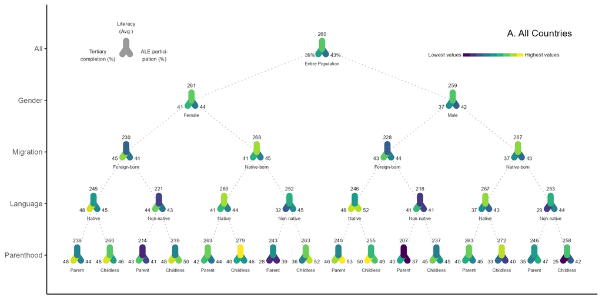

#### 6.2.4 B. Rich

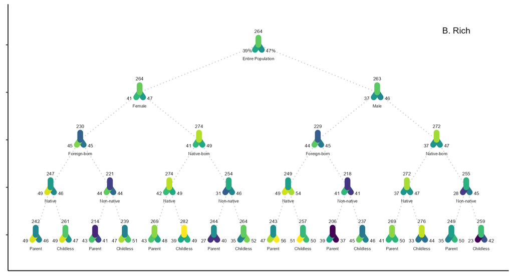

#### 6.2.5 C. Europe

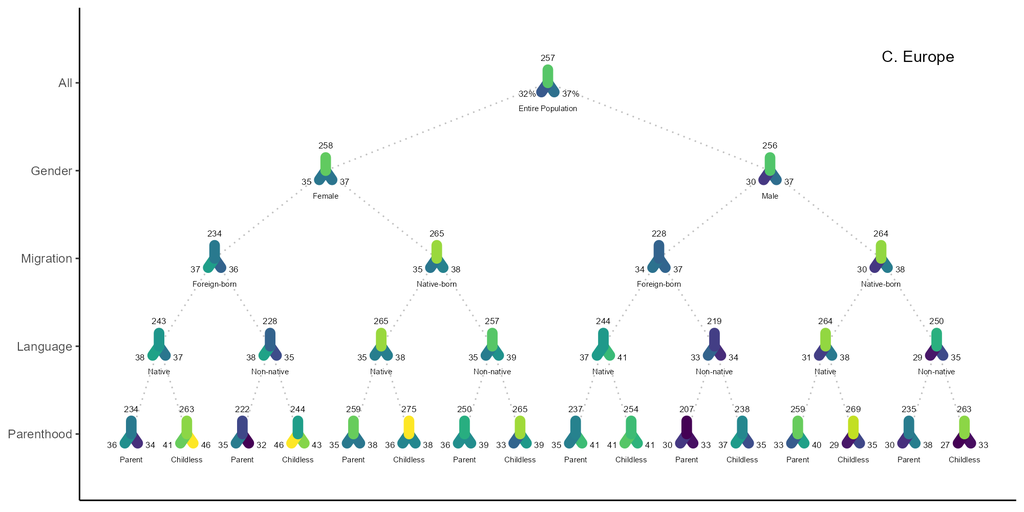

#### 6.2.6 D. DEU

##### 6.2.6.1 Lit English Labels

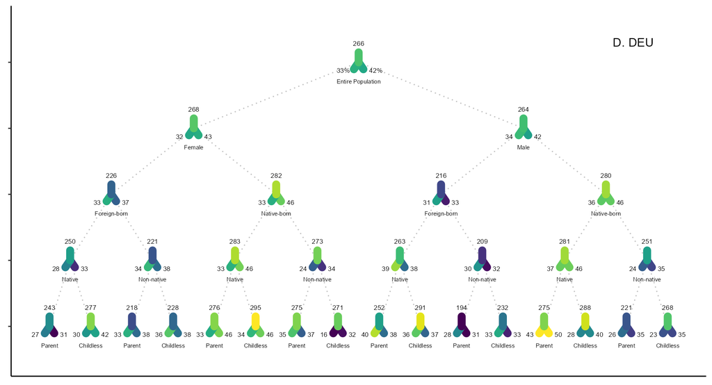

##### 6.2.6.2 Lit DE Labels

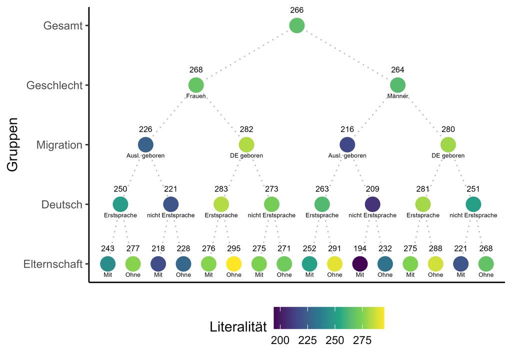

##### 6.2.6.3 Num DE Labels

[figure not shown]

## 7 Tbl S2. Intersectional Descriptives (16 Groups)

Descriptive Statistics for 16 Intersectional Groups (Cycle 2)

| Gender | Origin | Language | Parenthood | N (Cases) | Mean Literacy | ALE Participation (%) | Sec. Ed or Higher (%) |
| --- | --- | --- | --- | --- | --- | --- | --- |
| Male | Native-born | Native speaker | Parent | 29373 | 262.8 | 44.7 | 86.3 |
| Male | Native-born | Native speaker | Childless | 18353 | 271.8 | 40.4 | 87.2 |
| Male | Native-born | Non-native speaker | Parent | 1209 | 245.9 | 47.4 | 77.1 |
| Male | Native-born | Non-native speaker | Childless | 730 | 257.9 | 41.9 | 77.6 |
| Male | Foreign-born | Native speaker | Parent | 2074 | 240.5 | 53.4 | 75.9 |
| Male | Foreign-born | Native speaker | Childless | 1130 | 255.0 | 48.9 | 87.6 |
| Male | Foreign-born | Non-native speaker | Parent | 2595 | 206.9 | 37.4 | 69.3 |
| Male | Foreign-born | Non-native speaker | Childless | 1387 | 236.6 | 45.5 | 84.9 |
| Female | Native-born | Native speaker | Parent | 40523 | 263.1 | 43.8 | 87.8 |
| Female | Native-born | Native speaker | Childless | 14459 | 279.1 | 45.6 | 91.0 |
| Female | Native-born | Non-native speaker | Parent | 1459 | 242.6 | 39.2 | 74.9 |
| Female | Native-born | Non-native speaker | Childless | 652 | 262.8 | 51.9 | 85.4 |
| Female | Foreign-born | Native speaker | Parent | 2973 | 239.4 | 44.2 | 82.4 |
| Female | Foreign-born | Native speaker | Childless | 1011 | 259.8 | 46.3 | 87.9 |
| Female | Foreign-born | Non-native speaker | Parent | 3507 | 214.5 | 41.0 | 71.7 |
| Female | Foreign-born | Non-native speaker | Childless | 1244 | 238.9 | 50.0 | 88.9 |

### 7.1 Calculate sample size

Native born but non-native-speaking is very rare. Calculate percentages by group

## 8 Citations

```
## [[1]]
## Wickham H, Averick M, Bryan J, Chang W, McGowan LD, François R,
## Grolemund G, Hayes A, Henry L, Hester J, Kuhn M, Pedersen TL, Miller E,
## Bache SM, Müller K, Ooms J, Robinson D, Seidel DP, Spinu V, Takahashi
## K, Vaughan D, Wilke C, Woo K, Yutani H (2019). "Welcome to the
## tidyverse." _Journal of Open Source Software_, *4*(43), 1686.
## doi:10.21105/joss.01686 <https://doi.org/10.21105/joss.01686>.
##
## [[2]]
## Wickham H, Hester J, Bryan J (2024). _readr: Read Rectangular Text
## Data_. R package version 2.1.5,
## <https://CRAN.R-project.org/package=readr>.
##
## [[3]]
## Xie Y (2025). _knitr: A General-Purpose Package for Dynamic Report
## Generation in R_. R package version 1.50, <https://yihui.org/knitr/>.
##
## Xie Y (2015). _Dynamic Documents with R and knitr_, 2nd edition.
## Chapman and Hall/CRC, Boca Raton, Florida. ISBN 978-1498716963,
## <https://yihui.org/knitr/>.
##
## Xie Y (2014). "knitr: A Comprehensive Tool for Reproducible Research in
## R." In Stodden V, Leisch F, Peng RD (eds.), _Implementing Reproducible
## Computational Research_. Chapman and Hall/CRC. ISBN 978-1466561595.
##
## [[4]]
## Müller K (2020). _here: A Simpler Way to Find Your Files_. R package
## version 1.0.1, <https://CRAN.R-project.org/package=here>.
##
## [[5]]
## Wickham H (2016). _ggplot2: Elegant Graphics for Data Analysis_.
## Springer-Verlag New York. ISBN 978-3-319-24277-4,
## <https://ggplot2.tidyverse.org>.
##
## [[6]]
## Slowikowski K (2024). _ggrepel: Automatically Position Non-Overlapping
## Text Labels with 'ggplot2'_. R package version 0.9.6,
## <https://CRAN.R-project.org/package=ggrepel>.
##
## [[7]]
## Pedersen T, Shemanarev M (2024). _ragg: Graphic Devices Based on AGG_.
## R package version 1.3.3, <https://CRAN.R-project.org/package=ragg>.
##
## [[8]]
## Lumley T (2024). "survey: analysis of complex survey samples." R
## package version 4.4.
##
## Lumley T (2004). "Analysis of Complex Survey Samples." _Journal of
## Statistical Software_, *9*(1), 1-19. R package verson 2.2.
##
## Lumley T (2010). _Complex Surveys: A Guide to Analysis Using R: A Guide
## to Analysis Using R_. John Wiley and Sons.
##
## [[9]]
## Zhu H (2024). _kableExtra: Construct Complex Table with 'kable' and
## Pipe Syntax_. R package version 1.4.0,
## <https://CRAN.R-project.org/package=kableExtra>.
##
## [[10]]
## Wickham H, Pedersen T, Seidel D (2023). _scales: Scale Functions for
## Visualization_. R package version 1.3.0,
## <https://CRAN.R-project.org/package=scales>.
```

## 9 Colophon